# R Notebook

```r
library(rpart)
library(rpart.plot)
library(tidyverse)
library(ggplot2)
```

```r
titanic_set <- read_csv('data/titanic_decision_tree_data.csv')

shuffle_index <- sample(1:nrow(titanic_set))

# shuffle the data so class order isn't in order - need this for training/testing split later on
titanic_set <- titanic_set[shuffle_index, ]
```

```r
View(titanic_set)

dim(titanic_set)
```

```
[1] 1309   13
```

```r
library(tidyverse)
titanic_clean <- titanic_set %>%
  filter(survived %in% c(0,1)) %>%
# Convert to factor level
    mutate(sex = as.factor(sex),
           age_status = as.factor(if_else(age <= 16, "child", "adult")),
         class = factor(pclass, levels = c(3,2,1), labels = c("Lower", "Middle", "Upper")),
           survived_flag = factor(survived, levels = c(0,1), labels = c("No", "Yes")),
           port_embarkation = as.factor(embarked)) %>%
  select(sex, age_status, class, port_embarkation, sib_sp, parch, survived_flag) %>%
  na.omit()
```

1.2 Question 2

Have a look at your data and create some plots to ensure you know what you’re working with before you begin. Write a summary of what you have found in your plots. Which variables do you think might be useful to predict whether or not people are going to die? Knowing this before you start is the best way to have a sanity check that your model is doing a good job.

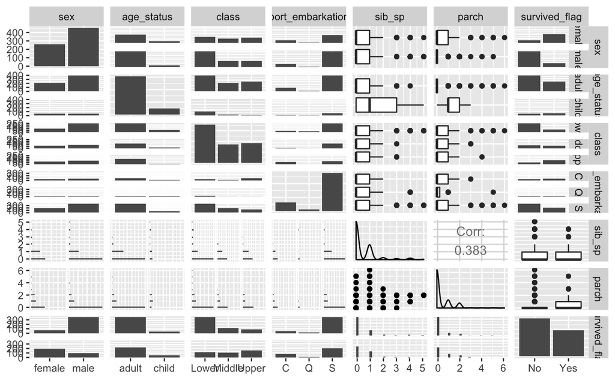

```r
library(GGally)
View(titanic_clean)
ggpairs(titanic_clean)
```

Question 3 Now you can start to build your model. Create your testing and training set using an appropriate split. Check you have balanced sets. Write down why you chose the split you did and produce output tables to show whether or not it is balanced.

```r
# get how many rows we have in total to work out the percentage
n_data <- nrow(titanic_clean)

# create a test sample index
test_index <- sample(1:n_data, size = n_data*0.2)

# create test set
titanic_test  <- slice(titanic_clean, test_index)

# create training set
titanic_train <- slice(titanic_clean, -test_index)
```

We can check that our test and training sets have similar proportions of deceased characters.

```r
library(janitor)
titanic_test %>%
 janitor::tabyl(survived_flag)
```

```
 survived_flag  n   percent
            No 86 0.6056338
           Yes 56 0.3943662
```

```r
titanic_train %>%
 janitor::tabyl(survived_flag)
```

```
 survived_flag   n   percent
            No 338 0.5929825
           Yes 232 0.4070175
```

Build tree model based on training dataset

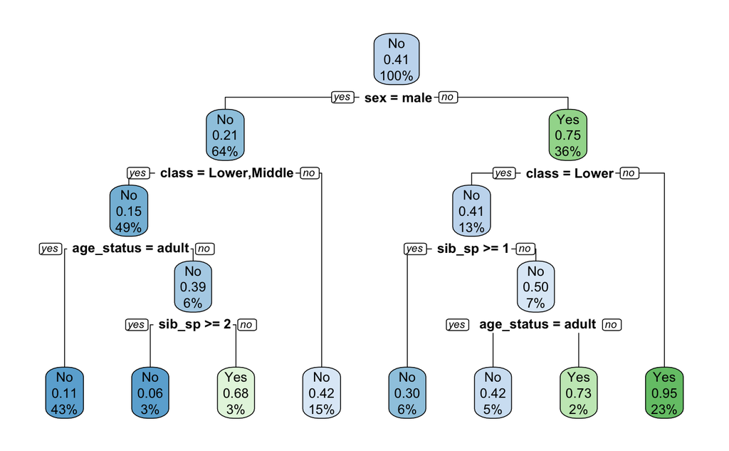

```r
titanic_fit <- rpart(survived_flag ~ .,
                     data = titanic_train,
                     method = 'class')

rpart.plot(titanic_fit, yesno = 2)
```

Let us now understand what our decision tree means:

To start with, the variables it has picked are the ones that are deemed most informative for predicting whether passengers of the Titanic will Survive or not. The rest have been discarded from our model. In our case it has picked sex, class, age_ststus, and sib_sp.

The predicted result for a datapoint at the node (Survived in this example) is on the top line.

Use trained model to create predictions on test dataset

```r
library(modelr)

# add the predictions
titanic_test_pred <- titanic_test %>%
                 add_predictions(titanic_fit, type = 'class')
```

Now we can look at our predictions. For the sake of keeping the variables reduced, let’s choose the ones that our decision tree model showed as most informative.

```r
# look at the variables
titanic_test_pred %>%
  select(sex, class, age_status, sib_sp, pred)
```

| sex | class | age_status | sib_sp | pred |
| --- | --- | --- | --- | --- |
| female | Middle | child | 1 | Yes |
| male | Middle | adult | 0 | No |
| male | Lower | adult | 0 | No |
| female | Middle | adult | 0 | Yes |
| female | Upper | adult | 0 | Yes |
| female | Middle | adult | 1 | Yes |
| male | Upper | adult | 0 | No |
| male | Lower | adult | 0 | No |
| male | Lower | adult | 0 | No |
| male | Lower | adult | 0 | No |

[output cut: 132 more lines]

Question 6 Test and add your predicitons to your data. Create a confusion matrix. Write down in detial what this tells you for this specific dataset.

Answer - Checking model performance - By Creating Confusion Matrix

```r
library(yardstick)

conf_mat <- titanic_test_pred %>%
              conf_mat(truth = survived_flag, estimate = pred)

conf_mat
```

```
          Truth
Prediction No Yes
       No  80  25
       Yes  6  31
```

Also Checking Accuracy of the model

```r
accuracy <- titanic_test_pred %>%
 accuracy(truth = survived_flag, estimate = pred)

accuracy
```

| .metric | .estimator | .estimate |
| --- | --- | --- |
| accuracy | binary | 0.7816901 |

Looks like the model has performed as at the moment it is showing 78% Accuracy